# Example

Julia Haaf

# Qualitative Individual Differences

For my dissertation I developed a model comparison approach to assess individual differences in simple cognitive tasks. This development is published in Haaf & Rouder (2017, Psych Methods). Here, I want to provide a function for the *Does everyone t-test*. The idea is if you have such a simple cognitive task with response time data from many trials per participant in two conditions, you can use the function to test whether everyone has an effect in the same, expected direction, or whether individuals truly and qualitatively vary in their effect.

## Data Example

Here, let’s use a Stroop data example. The data are from Von Bastian et al. (2015, JEP:General) who conducted a STroop task with 121 participants. The data are open and available at a github repository, and they can be sources using `curl()`. Here, the data are loaded and cleaned:

```r
library(curl)

filename <- curl::curl("https://raw.githubusercontent.com/PerceptionCognitionLab/data0/master/contexteffects/FlankerStroopSimon/LEF_stroop.csv")
stroop <- read.csv2(filename, header=TRUE, dec=".")

stroop$cond <- as.numeric(stroop$congruency)  #congruent -> 1, incongruent -> 2, neutral -> 3
ntrial <- length(stroop[stroop$ID == stroop$ID[1], 1])
nsub <- length(unique(stroop$ID))
stroop$trial <- rep(1:ntrial, nsub)
stroop$rt <- stroop$RT/1000 #rt data in seconds, not necessary

stroop <- stroop[stroop$rt > .2 & stroop$rt < 2, ]
stroop <- subset(stroop, accuracy == 1 & cond != 3) # the critical contrast is between congruent and incongruent

dat <- data.frame(stroop$ID, stroop$cond, stroop$rt)
colnames(dat) <- c('sub', 'cond', 'rt')
```

## QUID Test

Now, let’s apply the qualitative individual differences test using the function `quid()`. The function can be sourced from this github repository using `curl()`

```r
filename <- curl::curl("https://raw.githubusercontent.com/jstbcs/play/7288a543f1bbab494f2e939a6bda1f077b84c2a7/Qualitative%20Individual%20Differences/quid.R")
source(filename)
```

To use `quid()` you need three vectors containing:

1. an indicator of the participant (id = Participant ID)
2. an indicator of the condition (condition = two conditions)
3. the response times for each trial (rt)

Other arguments that can be changed are:

- prior = c(1/6, 1/10) (prior scale settings for the standard deviation of the overall effect and the individual effects)
- expect = list(lower = 1, higher = 2) (which value of condition represents the condition with the expected higher values, and lower values)
- iter = 10000 (number of iterations for the posterior sampling)
- burnin = 1000 (number of to be discarded burn-in iterations)

Here the function is called using the Stroop data loaded above.

```r
res <- quid(id = dat$sub, condition = dat$cond, rt = dat$rt)
```

[output not shown]

The object `res()` contains the Bayes factors, estimates from the unconstrained model for each individuals’ effect, some mcmc objects that can be used for inspection and plotting, etc. Here is how it can be accessed.

- Bayes factors

```r
res$bfs
```

```
##        bf.1u        bf.pu        bf.0u
## 1.021151e+00 6.366742e+00 1.035734e-62
```

- Individuals’ effects

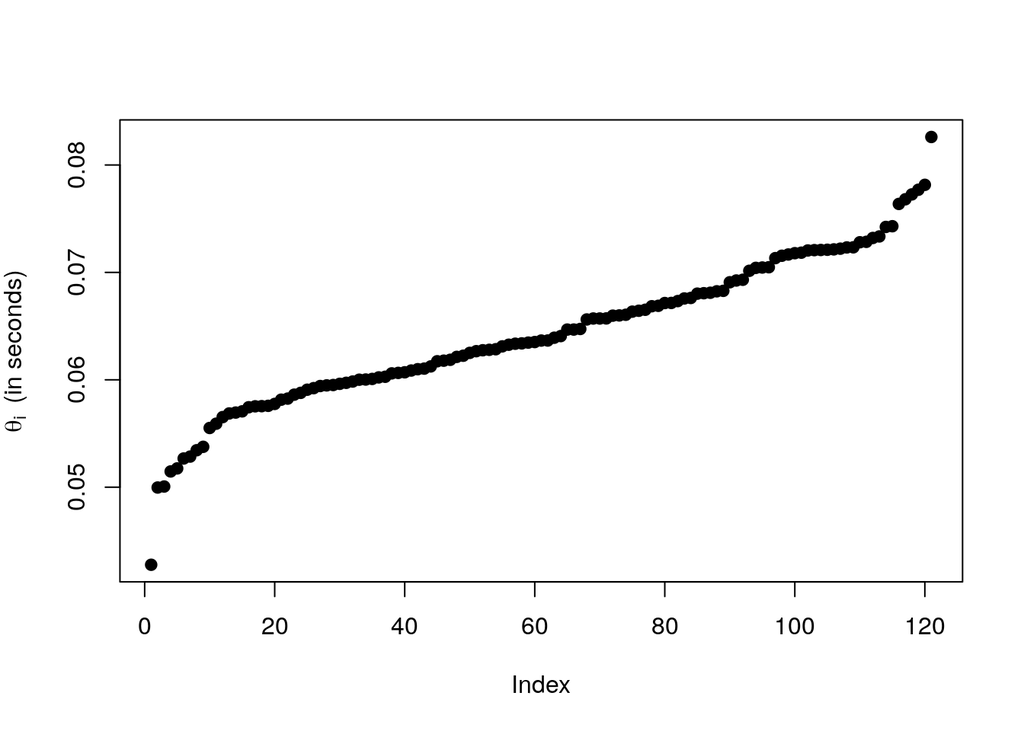

```r
plot(sort(res$ind.effects), pch = 19, ylab = expression(theta[i] ~ "(in seconds)"))
```

The estimated overall effect is 64 ms, and individual effects vary with a standard deviation of 7 ms around that mean. The positive-effects model is preferred with a Bayes factor of 6.37 to 1 over the unconstrained model indicating evidence that all individuals’ effects are truly positive.